# Introduction to ggplot2

Week 5 — Introduction to Data Visualization

# 1 Introduction

This week you’ll learn how to make clear and effective data visualizations in R with `ggplot2`.

**Core idea**: `ggplot2` is built on the *grammar of graphics* → plots are constructed by combining data, aesthetics (`aes()`), and geometric layers (`geom_*`).

**Core functions**:

- `ggplot(data, aes(x, y))` – initialize a plot with data and mappings
- `geom_point()`, `geom_bar()`, `geom_boxplot()` – common plot types
- `labs(title = , x = , y = )` – add labels
- `theme_minimal()`, `theme_bw()` – adjust themes
- `scale_x_*()`, `scale_y_*()`, `scale_color_*()` – fine-tune scales and colors

**Main points**:

1. Start with data + aesthetics + geom to build any plot.
2. Add layers to customize appearance and improve clarity.
3. Always design visualizations with readability and reproducibility in mind.

Packages used in this lesson Core: `tidyverse` (which includes `ggplot2`) and `dslabs` (datasets). Add-ons for the finishing touches: `ggthemes`, `ggrepel`, `gridExtra`, `RColorBrewer`, and `scales`. Install any you don’t have with `install.packages("...")`, and keep `crimson.css` in the same folder when you knit.

# 2 Data Visualization and Exploratory Data Analysis

Looking at the numbers and character strings that define a dataset is rarely useful. To convince yourself, print and stare at this data table:

```r
library(tidyverse)   # Loads ggplot2 (plotting) and dplyr (wrangling)
library(dslabs)      # Practice datasets
data(murders)        # U.S. gun murders by state (2010)
head(murders)        # Print the first 6 rows
```

|  | state | abb | region | population | total |
| --- | --- | --- | --- | --- | --- |
| 1 | Alabama | AL | South | 4779736 | 135 |
| 2 | Alaska | AK | West | 710231 | 19 |
| 3 | Arizona | AZ | West | 6392017 | 232 |
| 4 | Arkansas | AR | South | 2915918 | 93 |
| 5 | California | CA | West | 37253956 | 1257 |
| 6 | Colorado | CO | West | 5029196 | 65 |

What do you learn from staring at this table? How quickly can you determine which states have the largest populations? Which states have the smallest? How large is a typical state? Is there a relationship between population size and total murders? How do murder rates vary across regions of the country? For most human brains it is quite difficult to extract this information just from looking at the numbers. In contrast, the answer to all the questions above are readily available from examining this plot:

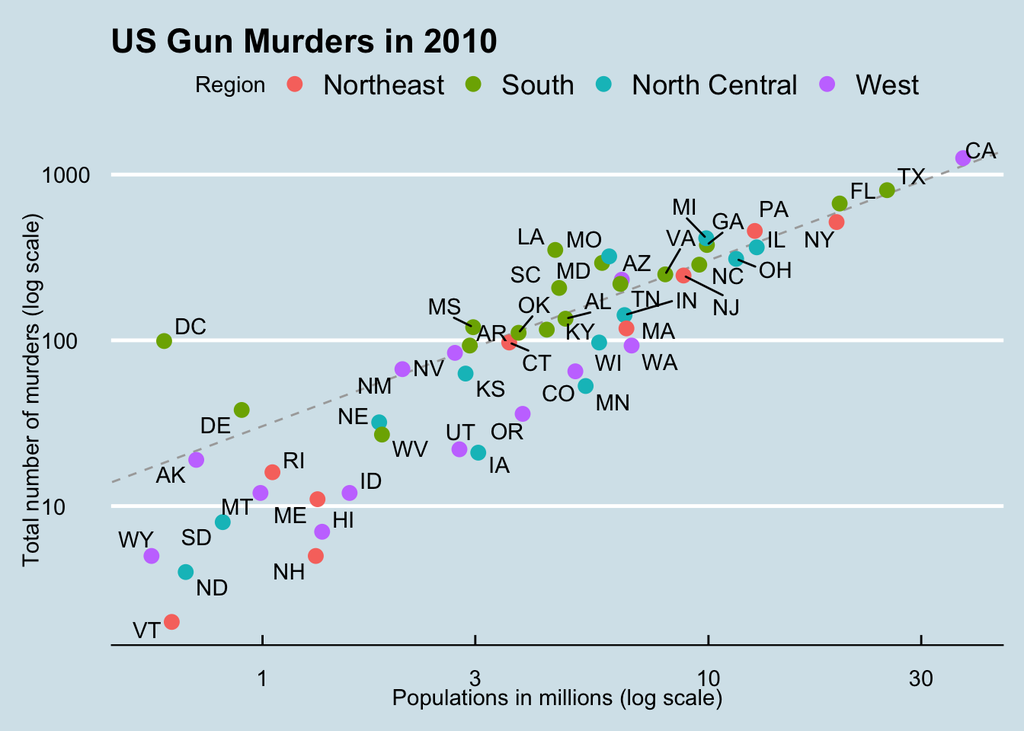

```r
library(ggthemes)   # Extra plot themes (e.g. theme_economist)
library(ggrepel)    # Labels that don't overlap (geom_text_repel)

# Compute the national murder rate per MILLION, to draw an "average" reference line.
r <- murders %>%
  summarize(pop = sum(population), tot = sum(total)) %>%   # National totals
  mutate(murder_rate = tot / pop * 10^6) %>%               # Rate per million
  .$murder_rate                                            # Pull out the single value

murders %>% ggplot(aes(x = population/10^6, y = total, label = abb)) +
  geom_abline(intercept = log10(r), lty = 2, col = "darkgrey") +  # US-average reference line
  geom_point(aes(color = region), size = 3) +                     # One point per state, colored by region
  geom_text_repel() +                                             # State abbreviations, non-overlapping
  scale_x_log10() +                                               # Log scale spreads out small states
  scale_y_log10() +
  xlab("Populations in millions (log scale)") +
  ylab("Total number of murders (log scale)") +
  ggtitle("US Gun Murders in 2010") +
  scale_color_discrete(name = "Region") +
  theme_economist()                                               # The Economist magazine style
```

We are reminded of the saying, “a picture is worth a thousand words”. Data visualization provides a powerful way to communicate a data-driven finding. In some cases, the visualization is so convincing that no follow-up analysis is required. We also note that many widely used data analysis tools were initiated by discoveries made via exploratory data analysis (EDA). EDA is perhaps the most important part of data analysis, yet is often overlooked.

With the talks [New Insights on Poverty](https://www.ted.com/talks/hans_rosling_reveals_new_insights_on_poverty?language=en) and [The Best Stats You’ve Ever Seen](https://www.ted.com/talks/hans_rosling_shows_the_best_stats_you_ve_ever_seen), Hans Rosling forced us to notice the unexpected with a series of plots related to world health and economics. In his videos, he used animated graphs to show us how the world was changing and that old narratives are no longer true. We will use this data as an example to learn about `ggplot2` and data visualization.

It is also important to note that mistakes, biases, systematic errors and other unexpected problems often lead to data that should be handled with care. Failure to discover these problems often leads to flawed analyses and false discoveries. As an example, consider that measurement devices sometimes fail and that most data analysis procedures are not designed to detect these.

Yet, these data analysis procedures will still give you an answer. The fact that it can be hard or impossible to notice an error just from the reported results, makes data visualization particularly important.

This week and next we will learn the basics of the `ggplot2` package - the software we will use to learn the basics of data visualization and exploratory data analysis. We will use motivating examples and start by reproducing the murders by state example to learn the basics of `ggplot2`. Then we will cover world health and economics and infectious disease trends in the United States.

Note that there is much more to data visualization than what we cover here. More references include:

- ER Tufte (1983) The visual display of quantitative information. Graphics Press.
- ER Tufte (1990) Envisioning information. Graphics Press.
- ER Tufte (1997) Visual explanations. Graphics Press.
- A Gelman, C Pasarica, R Dodhia (2002) Let’s practice what we preach: Turning tables into graphs. The American Statistician 56:121-130
- NB Robbins (2004) Creating more effective graphs. Wiley
- Cole Nussbaumer Knaflic (2015) [Storytelling with Data](https://www.storytellingwithdata.com/books)
- Rob Kabacoff (2018) [Data Visualization with R](https://rkabacoff.github.io/datavis/)
- [R Shiny](https://shiny.rstudio.com/)

# 3 A first introduction to `ggplot2`

We will be using the [`ggplot2`](https://ggplot2.tidyverse.org/) package, which loads as part of the tidyverse.

One reason `ggplot2` is generally more intuitive for beginners is that it uses a *grammar of graphics*, the *gg* in `ggplot2`. This is analogous to the way learning grammar can help a beginner construct hundreds of different sentences by learning just a handful of verbs, nouns and adjectives without having to memorize each specific sentence. Similarly, by learning a handful of `ggplot2` building blocks and its grammar, you will be able to create hundreds of different plots.

Another reason `ggplot2` makes it easier for beginners is that its default behavior is carefully chosen to satisfy the great majority of cases and are aesthetically pleasing. As a result, it is possible to create informative and elegant graphs with relatively simple and readable code.

One limitation is that ggplot is designed to work exclusively with data tables in which rows are observations and columns are variables. However, a substantial percentage of datasets that beginners work with are, or can be converted into, this format. An advantage of this approach is that assuming that our data follows this format simplifies the code and learning the grammar.

## 3.1 The Cheat Sheet

To use `ggplot2` you will have to learn several functions and arguments. These are hard to memorize so we highly recommend you have the [ggplot2 cheat sheet](https://www.rstudio.com/resources/cheatsheets/) handy.

## 3.2 The components of a graph

We construct a graph that summarizes the US murders dataset. Here is the finished plot again — our target for the rest of this section:

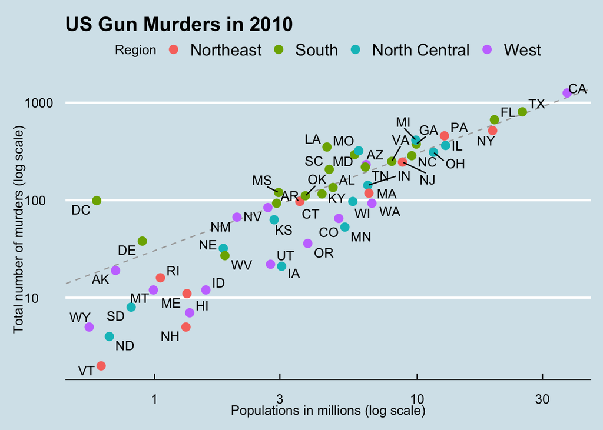

We can clearly see how much states vary across population size and the total number of murders. Not surprisingly, we also see a clear relationship between murder totals and population size. A state falling on the dashed grey line has the same murder rate as the US average. The four geographic regions are denoted with color and depicts how most southern states have murder rates above the average.

This data visualization shows us pretty much all the information in the data table. The code needed to make this plot is relatively simple. We will learn to create the plot part by part.

The first step in learning `ggplot2` is to be able to break a graph apart into components. Let’s break down this plot and introduce some of the `ggplot2` terminology. The three main components to note are:

1. **Data**: The US murders data table is being summarized. We refer to this as the **data** component.
2. **Geometry**: The plot above is a scatter plot. This is referred to as the **geometry** component. Other possible geometries are barplots, histograms, smooth densities, qqplots, and boxplots.
3. **Aesthetic mapping**: The x-axis values are used to display population size, the y-axis values are used to display the total number of murders, text is used to identify the states, and colors are used to denote the four different regions. These are the **aesthetic mappings** component. How we define the mapping depends on what **geometry** we are using.

We also note that:

4. The range of the x-axis and y-axis appears to be defined by the range of the data. They are both on log-scales. We refer to this as the **scale** component.
5. There are labels, a title, a legend, and we use the style of The Economist magazine for this particular plot.

We will now construct the plot piece by piece.